# lab7

Lucy Shao

March 21, 2017

# 1. Some movies ran longer, and some earned more. (20 points)

```r
load('/Users/lucy/Downloads/Movies_1A.RData')
#i
library(dplyr)
```

```r
library(ggplot2)
movie<-merge(moviesA, moviesB,all=TRUE)
oneA<- movie %>% mutate(
  OPEN=as.Date(movie$OPEN,format="%m/%d/%Y"),
  CLOSE=as.Date(movie$CLOSE,format="%m/%d/%Y")
) %>% mutate(
  RUN=movie$CLOSE-movie$OPEN
)%>% top_n(1, RUN)
##longest run
oneA
```

```
##  [1] RANK       TITLE      STUDIO     TOTGROSS   WTHEATERS  WEEK1GROSS
##  [7] OTHEATERS  OPEN       CLOSE      RUN
## <0 rows> (or 0-length row.names)
```

### 1b

```r
oneB<-movie %>% mutate(
  TOTGROSS=as.numeric(TOTGROSS)
)%>% top_n(1, TOTGROSS)
oneB
```

```
##   RANK      TITLE STUDIO TOTGROSS WTHEATERS WEEK1GROSS OTHEATERS     OPEN
## 1  696 Demi-Soeur Rialto     1382         1       $634         1 2/7/2014
##       CLOSE
## 1 2/13/2014
```

# 2. NBA 2015-2016 game results. (20 points)

Please download NBA16BOX.Rdata from CCLE week 7 and load it into R. This dataset contains 1316 game results from 2015-2016 NBA season including regular season and playoffs. ###2a. The best offensive team at home. Find the average points got for each team at home using a pipe including the following steps: i. Group your data frame by the variable HomeTeam using group_by() ii. Create a summary variable AvgHomePoints (average of HomePoints) using summarise() iii. Order the data frame by the variable AvgHomePoints in a decreasing order using arrange().

```r
load('/Users/lucy/Downloads/NBA16BOX.RData')
twoA<-nba16 %>% group_by(HomeTeam) %>% summarise(AvgHomePoints=mean(HomePoints)) %>% arrange(desc(AvgHomePoints))
twoA
```

```
## # A tibble: 30 × 2
##                  HomeTeam AvgHomePoints
##                     <chr>         <dbl>
## 1   Golden State Warriors      114.3455
## 2   Oklahoma City Thunder      109.4600
## 3  Portland Trail Blazers      108.1522
## 4        Sacramento Kings      107.5610
## 5     Cleveland Cavaliers      107.5098
## 6      Washington Wizards      106.0244
## 7    New Orleans Pelicans      105.9268
## 8          Boston Celtics      105.7955
## 9         Houston Rockets      105.7674
## 10      San Antonio Spurs      104.8478
## # ... with 20 more rows
```

### 2b. Numbers of home wins for each team in regular and post season.

Find the number of wins for each team separated by regular season and playoffs using a pipe including the following steps: i. Group your data frame by the variables HomeTeam and Playoffs using group_by() ii. Create a new variable HomeWins (HomePoints > VisitorPoints) using mutate() iii. Create a summary variable NumberOfHomeWins (sum of HomeWins) using summarise() iv. Order the data frame by the variable NumberOfHomeWins in a decreasing order using arrange().

```r
twoB<-nba16 %>% group_by(HomeTeam,Playoffs) %>% mutate(HomeWins=(HomePoints > VisitorPoints)) %>% summarise(NumberOfHomeWins=sum(HomeWins)) %>% arrange(desc((NumberOfHomeWins)))
twoB
```

```
## Source: local data frame [46 x 3]
## Groups: HomeTeam [30]
##
##                  HomeTeam       Playoffs NumberOfHomeWins
##                     <chr>          <chr>            <int>
## 1       San Antonio Spurs Regular Season               40
## 2   Golden State Warriors Regular Season               39
## 3     Cleveland Cavaliers Regular Season               33
## 4   Oklahoma City Thunder Regular Season               32
## 5         Toronto Raptors Regular Season               32
## 6       Charlotte Hornets Regular Season               30
## 7    Los Angeles Clippers Regular Season               29
## 8          Boston Celtics Regular Season               28
## 9              Miami Heat Regular Season               28
## 10 Portland Trail Blazers Regular Season               28
## # ... with 36 more rows
```

### 2c. The best defensive team at home in the regular season.

Find the average HomePoints and VisitorPoints by each HomeTeam for the regular season using a pipe including the following steps: i. Extra the observations with Playoffs == ‘Regular Season’ using filter() ii. Group your data frame by the variables HomeTeam using group_by() iii. Create two summary variables AvgHomePoints (average of HomePoints) and AvgVisitorPoints (average of VisitorPoints) using summarise() iv. Order the data frame by the variable VisitorPoints in a increasing order using arrange().

```r
twoC<-nba16 %>% filter(Playoffs == 'Regular Season')%>%group_by(HomeTeam) %>% summarise( AvgHomePoints=mean(HomePoints), VisitorPoints=mean(VisitorPoints)) %>% arrange(VisitorPoints)
twoC
```

```
## # A tibble: 30 × 3
##                 HomeTeam AvgHomePoints VisitorPoints
##                    <chr>         <dbl>         <dbl>
## 1      San Antonio Spurs     105.14634      91.17073
## 2              Utah Jazz      98.56098      93.04878
## 3          Atlanta Hawks     103.58537      97.68293
## 4             Miami Heat     103.21951      97.85366
## 5   Los Angeles Clippers     104.80488      97.92683
## 6    Cleveland Cavaliers     106.63415      98.39024
## 7        Toronto Raptors     104.95122      98.39024
## 8         Indiana Pacers     102.90244      98.85366
## 9      Charlotte Hornets     105.46341      99.09756
## 10 Oklahoma City Thunder     109.53659      99.68293
## # ... with 20 more rows
```

# 3. Acidity is a fundamental property of wine. (20 points)

Please read the data from this website http://ieor.berkeley.edu/~ieor265/homeworks/winequality-red.csv with proper function and arguments. It is a dataset of wine quality. Please reproduce the following scatter plot using a pipe including the following steps: i. Create a new variable named fixed.acidity.log2 (log2 transformed fixed.acidity) to the data frame using mutate() ii. Create a null plot using ggplot iii. Add points fixed.acidity.log2 against pH using geom_point() iv. Add a regression line with a confidence band using geom_smooth().

```r
data3<-read.csv("http://ieor.berkeley.edu/~ieor265/homeworks/winequality-red.csv",header = TRUE,sep = ';')
head(data3)
```

```
##   fixed.acidity volatile.acidity citric.acid residual.sugar chlorides
## 1           7.4             0.70        0.00            1.9     0.076
## 2           7.8             0.88        0.00            2.6     0.098
## 3           7.8             0.76        0.04            2.3     0.092
## 4          11.2             0.28        0.56            1.9     0.075
## 5           7.4             0.70        0.00            1.9     0.076
## 6           7.4             0.66        0.00            1.8     0.075
##   free.sulfur.dioxide total.sulfur.dioxide density   pH sulphates alcohol
## 1                  11                   34  0.9978 3.51      0.56     9.4
## 2                  25                   67  0.9968 3.20      0.68     9.8
## 3                  15                   54  0.9970 3.26      0.65     9.8
## 4                  17                   60  0.9980 3.16      0.58     9.8
## 5                  11                   34  0.9978 3.51      0.56     9.4
## 6                  13                   40  0.9978 3.51      0.56     9.4
##   quality
## 1       5
## 2       5
## 3       5
## 4       6
## 5       5
## 6       5
```

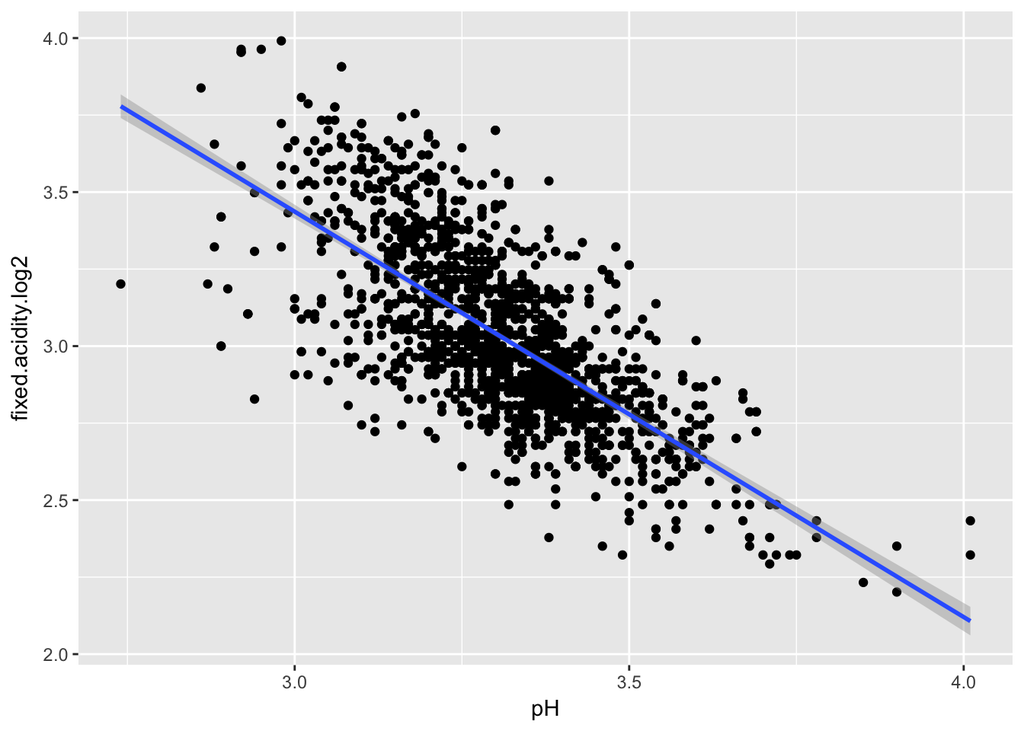

```r
ggplot(data =mutate(data3,fixed.acidity.log2=log2(data3$fixed.acidity))) + geom_point(mapping = aes(x = pH, y=fixed.acidity.log2)) + geom_smooth(mapping = aes(x = pH, y = fixed.acidity.log2),method = "lm", se = TRUE)
```

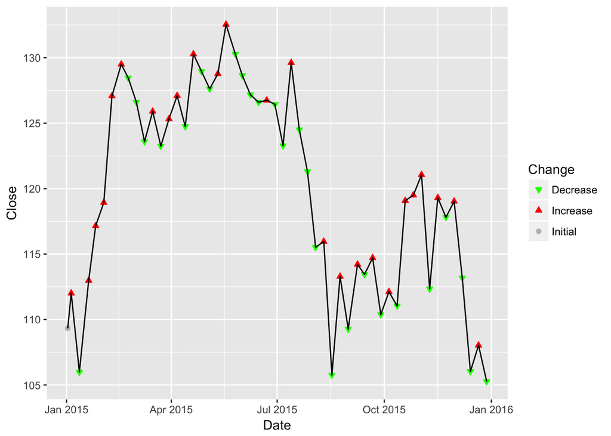

```r
aapl<-read.csv("http://real-chart.finance.yahoo.com/table.csv?s=AAPL&a=00&b=1&c=2015&d=11&e=31&f=2015&g=w&ignore=.csv",header = TRUE)
aapl %>% mutate( Date=as.Date(Date)) %>% arrange(Date)%>%mutate(Change =factor(c('Increase', 'Decrease', 'Initial')[c(2,
diff(Close) < 0) + 1])) %>% ggplot() + geom_point(mapping = aes(x = Date, y = Close, color = Change,shape = Change, fill
= Change))+ geom_path(mapping = aes(x = Date, y = Close))+scale_shape_manual(values = c(25, 24, 19))+scale_color_manual(values = c('green', 'red', 'gray'))+ scale_fill_manual(values = c('green', 'red', 'gray'))
```

#5. Permutation test (Bonus 10 points) We have learned the two sample t-test to test the null hypothesis H0: the mean of the Sepal.Width between versicolor and virginica (assuming the variance are the same for the two species). We can extract the observed t-statistics and the p-value by

```r
iris2 <- filter(iris, Species %in% c('versicolor', 'virginica'))
t_obs <- t.test(iris2$Sepal.Width ~ iris2$Species, var.equal = TRUE)$statistic
pv_obs <- t.test(iris2$Sepal.Width ~ iris2$Species, var.equal = TRUE)$p.value
t_obs
```

```
##         t
## -3.205761
```

```r
pv_obs
```

```
## [1] 0.0018191
```

```r
set.seed(2017)
t_perm<-vector(length=10000)
for(i in 1:10000){
a<-t.test(iris2$Sepal.Width ~ sample(iris2$Species), var.equal = TRUE)$statistic
t_perm<-c(t_perm,a)
}
pv_perm<-sum(abs(t_perm) >abs(t_obs))/10000
pv_perm
```

```
## [1] 0.0013
```